# Perspectives On Romantic Relationships

- Show All Code
- Hide All Code
- View Source

PSY 120L Reproducible Analysis Report

Author

Natalie Byrnes

Published

June 7, 2026

## About This Report

This is a reproducible report documenting an overview of the data preparation, variable construction and operationalization, descriptive statistics, analyses, and figures for this study.

This report is intended to be published along with a manuscript-style research paper. It is not the complete paper, however it describes how the reported analyses were produced from the dataset using a transparent and reproducible Quarto workflow.

## Study Overview

This study examined whether social approval influences individuals’ feelings and evaluations of their romantic relationships, and whether or not susceptibility to interpersonal influence moderates this effect.

This study design included one manipulated independent variable as well as one categorical moderator:

- Social Approval Condition: High social approval versus low social approval
- Susceptibility to Interpersonal Influence: High susceptibility versus low susceptibility

The dependent variables measured in this study were relationship commitment and relationship satisfaction scores. The primary analyses examined whether social approval condition (high vs. low), susceptibility level (high or low susceptibility), as well as the interaction between approval and susceptibility predicted relationship commitment and relationship satisfaction.

## Setup and Software Environment

This section loads the packages used for data preparation, scale construction, statistical modeling, estimated marginal means, and figures.

**Load Packages**

```r
library(tidyverse)  # data manipulation + plotting
library(psych)      # scale construction + reliability
library(afex)       # ANOVA models + effect sizes
library(emmeans)    # estimated marginal means + confidence intervals
```

## Data Source and Analysis Dataset

The dataset was imported from the project data folder. The imported dataset was saved as study_raw so that the original file remained unchanged throughout the report.

A smaller analysis dataset was then created for the current analyses. This dataset retained the study condition variable, demographic variables, relationship assessment items, commitment items, and susceptibility items needed for variable preparation and analysis.

### Import Dataset

```r
study_raw <- read_csv("data/relationships_data.csv")
```

### Check Imported Dataset

```r
dim(study_raw)
```

```
[1] 75 41
```

```r
names(study_raw)
```

```
 [1] "StartDate"             "EndDate"               "Status"
 [4] "IPAddress"             "Progress"              "Duration (in seconds)"
 [7] "Finished"              "RecordedDate"          "ResponseId"
[10] "ExternalReference"     "LocationLatitude"      "LocationLongitude"
[13] "DistributionChannel"   "UserLanguage"          "Q34"
[16] "ras1"                  "ras2"                  "ras3"
[19] "ras4"                  "ras5"                  "ras6"
[22] "ras7"                  "commit1"               "commit2"
[25] "commit3"               "commit4"               "commit5"
[28] "commit6"               "commit7"               "suscep1"
[31] "suscep2"               "suscep3"               "suscep4"
[34] "suscep5"               "suscep6"               "suscep7"
[37] "suscep8"               "age"                   "gender"
[40] "relationship"          "condition"
```

```r
head(study_raw)
```

```
# A tibble: 6 × 41
  StartDate    EndDate Status IPAddress Progress Duration (in seconds…¹ Finished
  <chr>        <chr>    <dbl> <chr>        <dbl>                  <dbl>    <dbl>
1 5/5/26 19:11 5/5/26…      0 174.194.…      100                    312        1
2 5/5/26 20:05 5/5/26…      0 72.205.8…      100                    188        1
3 5/5/26 20:15 5/5/26…      0 165.85.5…      100                    150        1
4 5/5/26 20:34 5/5/26…      0 172.226.…      100                    187        1
5 5/5/26 21:23 5/5/26…      0 174.221.…      100                    280        1
6 5/5/26 21:22 5/5/26…      0 108.147.…      100                    455        1
# ℹ abbreviated name: ¹`Duration (in seconds)`
# ℹ 34 more variables: RecordedDate <chr>, ResponseId <chr>,
#   ExternalReference <lgl>, LocationLatitude <dbl>, LocationLongitude <dbl>,
#   DistributionChannel <chr>, UserLanguage <chr>, Q34 <dbl>, ras1 <dbl>,
#   ras2 <dbl>, ras3 <dbl>, ras4 <dbl>, ras5 <dbl>, ras6 <dbl>, ras7 <dbl>,
#   commit1 <dbl>, commit2 <dbl>, commit3 <dbl>, commit4 <dbl>, commit5 <dbl>,
#   commit6 <dbl>, commit7 <dbl>, suscep1 <dbl>, suscep2 <dbl>, …
```

The import checks confirm that the dataset loaded successfully, show the number of rows and columns, and display the variable names available in the original dataset.

### Create Analysis Dataset

```r
study_vars <- c(
  "condition",  # experimental condition variable
  "age", "gender", "relationship",

      "ras1", "ras2","ras3","ras4","ras5","ras6","ras7",

      "commit1","commit2","commit3","commit4","commit5","commit6","commit7",

      "suscep1","suscep2","suscep3","suscep4","suscep5","suscep6","suscep7","suscep8"

)


study_data <- study_raw %>%
  select(all_of(study_vars)) %>%
  mutate(across(everything(), as.numeric))
```

### Check Analysis Dataset

```r
length(study_vars)
```

```
[1] 26
```

```r
dim(study_data)
```

```
[1] 75 26
```

```r
names(study_data)
```

```
 [1] "condition"    "age"          "gender"       "relationship" "ras1"
 [6] "ras2"         "ras3"         "ras4"         "ras5"         "ras6"
[11] "ras7"         "commit1"      "commit2"      "commit3"      "commit4"
[16] "commit5"      "commit6"      "commit7"      "suscep1"      "suscep2"
[21] "suscep3"      "suscep4"      "suscep5"      "suscep6"      "suscep7"
[26] "suscep8"
```

The analysis dataset contains the variables required for the report. The checks confirm the number of selected variables, the dimensions of the analysis dataset, and the final variable names carried forward into the preparation and analysis sections.

## Variable Preparation

This section prepares the variables used in the primary analyses. The original imported dataset was left unchanged; all prepared variables were created in the working analysis dataset, study_data.

### Prepare Participant ID and Experimental Condition

```r
study_data <- study_data %>%
  mutate(
    id = row_number(),
    condition = factor(
      condition,
      levels = c(0, 1),
      labels = c("Low Social Approval", "High Social Approval")
    )
  )
```

The experimental condition variable was recoded as a labeled factor with two levels: Low Social Approval and High Social Approval. A participant ID variable was also created so that each row in the analysis dataset had a unique identifier.

### Check Experimental Condition Coding

```r
study_data %>%
  count(condition) %>%
  knitr::kable(
    col.names = c("Condition", "n")
  )
```

| Condition | n |
| --- | --- |
| Low Social Approval | 38 |
| High Social Approval | 37 |

The condition check confirms the number of participants assigned to each approval condition.

### Check Prepared Analysis Dataset

```r
dim(study_data)
```

```
[1] 75 27
```

```r
names(study_data)
```

```
 [1] "condition"    "age"          "gender"       "relationship" "ras1"
 [6] "ras2"         "ras3"         "ras4"         "ras5"         "ras6"
[11] "ras7"         "commit1"      "commit2"      "commit3"      "commit4"
[16] "commit5"      "commit6"      "commit7"      "suscep1"      "suscep2"
[21] "suscep3"      "suscep4"      "suscep5"      "suscep6"      "suscep7"
[26] "suscep8"      "id"
```

The prepared analysis dataset contains the variables needed for scale construction, descriptive statistics, and primary analysis.

### Reverse-Code Scale Items

Items requiring reverse coding were transformed before scale scores were computed.

RAS items 4 and 7 were reverse-coded using a 1-5 response scale (reverse = 6 - item).

Commitment items 4 and 5 were reverse-coded using a 1-7 response scale (reverse = 8 - item).

```r
# Reverse-code selected RAS items
study_data <- study_data %>%
  mutate(
    ras4_r = 6 - ras4, # reverse-codes ras4
    ras7_r = 6 - ras7, # reverse-codes ras7

    commit4_r = 8 - commit4, # reverse-codes commit4
    commit5_r = 8 - commit5 # reverse-codes commit5
  )
```

### Check Reverse Coding

```r
study_data %>%
  select(ras4_r, ras4, commit4_r, commit4) %>%
  head(10) %>%
  knitr::kable()
```

| ras4_r | ras4 | commit4_r | commit4 |
| --- | --- | --- | --- |
| 4 | 2 | 6 | 2 |
| 4 | 2 | 6 | 2 |
| 4 | 2 | 6 | 2 |
| 4 | 2 | 2 | 6 |
| 5 | 1 | 6 | 2 |
| 5 | 1 | 7 | 1 |
| 3 | 3 | 3 | 5 |
| 4 | 2 | 6 | 2 |
| 5 | 1 | 7 | 1 |
| 5 | 1 | 7 | 1 |

The reverse-coding check shows examples of original and reverse-coded item pairs for the RAS and commitment scales. These checks confirm that reverse-coded variables were created correctly before scale scores were computed.

### Create Scale Scores

Scale item lists were defined and used to compute relationship satisfaction (RAS), commitment, and susceptibility scale scores. All scale scores were computed as row means across the relevant items, with missing values excluded.

```r
# Relationship Assessment Scale items
ras_items <- c(
  "ras1",
  "ras2",
  "ras3",
  "ras4_r",
  "ras5",
  "ras6",
  "ras7_r"
)

# Rusbult Commitment Scale items
commit_items <- c(
  "commit1",
  "commit2",
  "commit3",
  "commit4_r",
  "commit5_r",
  "commit6",
  "commit7"
)

# Susceptibility Scale items
suscep_items <- c(
  "suscep1",
  "suscep2",
  "suscep3",
  "suscep4",
  "suscep5",
  "suscep6",
  "suscep7",
  "suscep8"
)


study_data <- study_data %>%
  mutate(
    ras_scale = rowMeans(across(all_of(ras_items)), na.rm = TRUE),
    commit_scale = rowMeans(across(all_of(commit_items)), na.rm = TRUE),
    suscep_scale = rowMeans(across(all_of(suscep_items)), na.rm = TRUE)
  )
```

### Check Scale Scores

```r
study_data %>%
  select(ras_scale, commit_scale, suscep_scale) %>%
  summary()
```

```
   ras_scale      commit_scale    suscep_scale
 Min.   :2.286   Min.   :2.857   Min.   :1.375
 1st Qu.:3.714   1st Qu.:4.857   1st Qu.:3.250
 Median :4.143   Median :6.000   Median :4.250
 Mean   :4.109   Mean   :5.718   Mean   :4.137
 3rd Qu.:4.714   3rd Qu.:6.714   3rd Qu.:4.938
 Max.   :5.000   Max.   :7.000   Max.   :6.625
```

```r
study_data %>%
  summarise(
    ras_missing = mean(is.na(ras_scale)),
    commit_missing = mean(is.na(commit_scale)),
    suscep_missing = mean(is.na(suscep_scale))
  ) %>%
  knitr::kable()
```

| ras_missing | commit_missing | suscep_missing |
| --- | --- | --- |
| 0 | 0 | 0 |

The scale-score checks confirm that the computed scale scores fall within the expected response range and show whether any scale scores were missing.

A low/high susceptibility grouping variable was created for the planned 2x2 ANOVA models. Participants with susceptibility scores at or below the sample median were assigned to the Low group, and participants above the sample median were assigned to the High group.

```r
suscep_median <- median(study_data$suscep_scale, na.rm = TRUE)

study_data <- study_data %>%
  mutate(
    suscep_msplit = if_else(suscep_scale <= suscep_median, "Low", "High"),
    suscep_msplit = factor(suscep_msplit, levels = c("Low", "High"))
  )

suscep_median
```

```
[1] 4.25
```

```r
study_data %>%
  count(suscep_msplit) %>%
  knitr::kable()
```

| suscep_msplit | n |
| --- | --- |
| Low | 38 |
| High | 37 |

The median split created the susceptibility grouping variable used in the primary ANOVA models. The output reports the median value used for the split and the number of participants assigned to each susceptibility group.

### Check Scale Reliability

Internal consistency was estimated for the relationship satisfaction, commitment, and susceptibility scales before the scale scores were used in the primary analyses.

```r
# Create item-only data frames for each scale
ras_item_df <- study_data %>% select(all_of(ras_items))
commit_item_df <- study_data %>% select(all_of(commit_items))
suscep_item_df <- study_data %>% select(all_of(suscep_items))

# Compute internal consistency estimates
ras_alpha <- psych::alpha(ras_item_df)
ras_omega <- psych::omega(ras_item_df, plot = FALSE)

commit_alpha <- psych::alpha(commit_item_df)
commit_omega <- psych::omega(commit_item_df, plot = FALSE)

suscep_alpha <- psych::alpha(suscep_item_df)
suscep_omega <- psych::omega(suscep_item_df, plot = FALSE)

# Print only alpha and omega coefficients
tibble(
  scale = c("Relationship Assessment", "Commitment", "Susceptibility"),
  alpha = c(
    ras_alpha$total$raw_alpha,
    commit_alpha$total$raw_alpha,
    suscep_alpha$total$raw_alpha
  ),
  omega = c(
    ras_omega$omega.tot,
    commit_omega$omega.tot,
    suscep_omega$omega.tot
  )
)
```

```
# A tibble: 3 × 3
  scale                   alpha omega
  <chr>                   <dbl> <dbl>
1 Relationship Assessment 0.916 0.939
2 Commitment              0.918 0.950
3 Susceptibility          0.874 0.913
```

The reliability table reports Cronbach’s alpha and McDonald’s omega for each scale used in the analysis.

## Descriptive Statistics

This section summarizes the scale scores and sample composition before the primary hypothesis tests.

### Scale Score Descriptives

```r
study_data %>%
  select(
    ras_scale,
    commit_scale,
    suscep_scale
  ) %>%
  psych::describe() %>%
  knitr::kable(digits = 2)
```

|  | vars | n | mean | sd | median | trimmed | mad | min | max | range | skew | kurtosis | se |
| --- | --- | --- | --- | --- | --- | --- | --- | --- | --- | --- | --- | --- | --- |
| ras_scale | 1 | 75 | 4.11 | 0.69 | 4.14 | 4.16 | 0.64 | 2.29 | 5.00 | 2.71 | -0.66 | -0.34 | 0.08 |
| commit_scale | 2 | 75 | 5.72 | 1.12 | 6.00 | 5.82 | 1.27 | 2.86 | 7.00 | 4.14 | -0.67 | -0.58 | 0.13 |
| suscep_scale | 3 | 75 | 4.14 | 1.18 | 4.25 | 4.17 | 1.11 | 1.38 | 6.62 | 5.25 | -0.28 | -0.52 | 0.14 |

The table reports descriptive statistics for the relationship satisfaction, commitment, and susceptibility scale scores used in the primary analyses.

### Sample Composition by Age, Gender, and Relationship

```r
study_data %>%
  summarise(
    mean_age = mean(age, na.rm = TRUE),
    sd_age = sd(age, na.rm = TRUE),
    min_age = min(age, na.rm = TRUE),
    max_age = max(age, na.rm = TRUE)
  ) %>%
  knitr::kable(
    digits = 2,
    col.names = c("Mean", "SD", "Minimum", "Maximum"),
    caption = "Sample Age: Mean, Standard Deviation, and Range"
  )
```

Sample Age: Mean, Standard Deviation, and Range

| Mean | SD | Minimum | Maximum |
| --- | --- | --- | --- |
| 26.33 | 12.9 | 19 | 73 |

```r
study_data %>%
  count(gender) %>%
  arrange(gender) %>%
  mutate(percent = round(100 * n / sum(n), 1)) %>%
  knitr::kable(
    col.names = c("Gender", "n", "Percent"),
    caption = "Sample Composition by Gender"
  )
```

Sample Composition by Gender

| Gender | n | Percent |
| --- | --- | --- |
| 1 | 15 | 20 |
| 2 | 60 | 80 |

```r
study_data %>%
  count(relationship) %>%
  arrange(relationship) %>%
  mutate(percent = round(100 * n / sum(n), 1)) %>%
  knitr::kable(
    col.names = c("Relationship", "n", "Percent"),
    caption = "Sample Composition by Year"
  )
```

| Relationship | n | Percent |
| --- | --- | --- |
| 1 | 29 | 38.7 |
| 2 | 43 | 57.3 |
| 3 | 3 | 4.0 |

The tables report the mean, standard deviation, and range of participant age, and the number and percentage of participants in each gender and relationship status category.

## Correlations Among the DVs

Before the primary analyses, correlations among the three scale scores were examined. This provides context for interpreting the ANOVA results and helps identify whether the dependent variables are related to one another.

```r
# Correlations for the relationship assessment, commitment, and susceptibility scales
psych::corr.test(
  study_data %>% select(ras_scale, commit_scale, suscep_scale)
)
```

```
Call:psych::corr.test(x = study_data %>% select(ras_scale, commit_scale,
    suscep_scale))
Correlation matrix
             ras_scale commit_scale suscep_scale
ras_scale         1.00         0.79        -0.10
commit_scale      0.79         1.00        -0.07
suscep_scale     -0.10        -0.07         1.00
Sample Size
[1] 75
Probability values (Entries above the diagonal are adjusted for multiple tests.)
             ras_scale commit_scale suscep_scale
ras_scale         0.00         0.00         0.76
commit_scale      0.00         0.00         0.76
suscep_scale      0.38         0.53         0.00

 To see confidence intervals of the correlations, print with the short=FALSE option
```

## Primary Analyses

This section reports the primary analyses used to test whether social approval condition, susceptibility group, and their interaction predicted commitment and relationship satisfaction scores. The two 2x2 ANOVA models were estimated. The first model used commitment as the dependent variable, and the second used relationship satisfaction. In both models, social approval condition was the manipulated independent variable and susceptibility group was the categorical moderator.

### **Commitment Model**

A 2x2 ANOVA tested whether commitment scores differed by social approval condition, susceptibility group, and the interaction between the condition and susceptibility group.

```r
# 2x2 between-subjects ANOVA predicting commitment scores
# DV: commit_scale
# Factors: condition and suscep_msplit
a1_commit <- afex::aov_ez(
  id = "id",
  dv = "commit_scale",
  between = c("condition", "suscep_msplit"),
  data = study_data
)

# Print the ANOVA table
a1_commit
```

```
Anova Table (Type 3 tests)

Response: commit_scale
                   Effect    df  MSE       F  ges p.value
1               condition 1, 71 1.15 7.88 ** .100    .006
2           suscep_msplit 1, 71 1.15    0.47 .007    .496
3 condition:suscep_msplit 1, 71 1.15    0.90 .013    .345
---
Signif. codes:  0 '***' 0.001 '**' 0.01 '*' 0.05 '+' 0.1 ' ' 1
```

The ANOVA table reports the main effect of condition, the main effect of susceptibility group, and the condition x susceptibility group interaction for commitment scores.

### Estimated Means for Relationship Commitment

```r
emmeans(a1_commit, ~ condition)
```

```
 condition            emmean    SE df lower.CL upper.CL
 Low Social Approval    5.37 0.174 71     5.02     5.72
 High Social Approval   6.06 0.176 71     5.71     6.42

Results are averaged over the levels of: suscep_msplit
Confidence level used: 0.95
```

```r
emmeans(a1_commit, ~ suscep_msplit)
```

```
 suscep_msplit emmean    SE df lower.CL upper.CL
 Low             5.80 0.174 71     5.45     6.15
 High            5.63 0.176 71     5.28     5.98

Results are averaged over the levels of: condition
Confidence level used: 0.95
```

```r
emmeans(a1_commit, ~ condition * suscep_msplit)
```

```
 condition            suscep_msplit emmean    SE df lower.CL upper.CL
 Low Social Approval  Low             5.57 0.240 71     5.09     6.05
 High Social Approval Low             6.03 0.253 71     5.53     6.54
 Low Social Approval  High            5.17 0.253 71     4.66     5.67
 High Social Approval High            6.10 0.246 71     5.61     6.59

Confidence level used: 0.95
```

The estimated means show the commitment score pattern across social approval condition, susceptibility group, and their combined cells.

### **Satisfaction** Model

A 2x2 ANOVA tested whether relationship satisfaction scores differed by social approval condition, susceptibility group, and the condition x susceptibility group interaction.

```r
a1_ras <- afex::aov_ez(
  id = "id",
  dv = "ras_scale",
  between = c("condition", "suscep_msplit"),
  data = study_data
)

# Print the ANOVA table
a1_ras
```

```
Anova Table (Type 3 tests)

Response: ras_scale
                   Effect    df  MSE       F  ges p.value
1               condition 1, 71 0.42 9.01 ** .113    .004
2           suscep_msplit 1, 71 0.42    1.61 .022    .208
3 condition:suscep_msplit 1, 71 0.42    2.44 .033    .123
---
Signif. codes:  0 '***' 0.001 '**' 0.01 '*' 0.05 '+' 0.1 ' ' 1
```

The ANOVA table reports the main effect of condition, the main effect of susceptibility group, and the condition x susceptibility group interaction for relationship satisfaction scores.

### Estimated Means for Relationship Satisfaction

```r
emmeans(a1_ras, ~ condition)
```

```
 condition            emmean    SE df lower.CL upper.CL
 Low Social Approval    3.88 0.106 71     3.67     4.09
 High Social Approval   4.33 0.107 71     4.12     4.54

Results are averaged over the levels of: suscep_msplit
Confidence level used: 0.95
```

```r
emmeans(a1_ras, ~ suscep_msplit)
```

```
 suscep_msplit emmean    SE df lower.CL upper.CL
 Low             4.20 0.106 71     3.99     4.41
 High            4.01 0.107 71     3.80     4.22

Results are averaged over the levels of: condition
Confidence level used: 0.95
```

```r
emmeans(a1_ras, ~ condition * suscep_msplit)
```

```
 condition            suscep_msplit emmean    SE df lower.CL upper.CL
 Low Social Approval  Low             4.09 0.146 71     3.80     4.38
 High Social Approval Low             4.31 0.153 71     4.00     4.62
 Low Social Approval  High            3.67 0.153 71     3.36     3.97
 High Social Approval High            4.35 0.149 71     4.06     4.65

Confidence level used: 0.95
```

The estimated means show the relationship satisfaction score pattern across social approval condition, susceptibility group, and their combined cells.

## Figures

This section creates the figures used to visualize the primary 2x2 ANOVA results. The figures are based on the estimated cell means from the ANOVA models.

### Commitment Interaction Plot

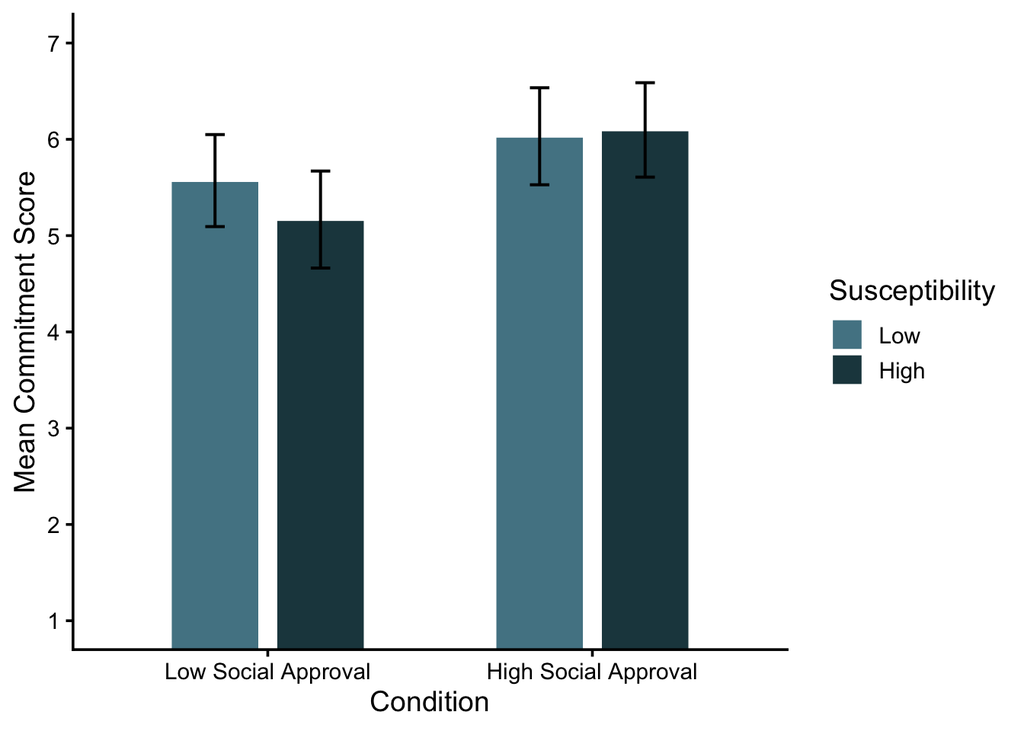

```r
p_commit_bar <- ggplot(
  as.data.frame(emmeans(a1_commit, ~ condition * suscep_msplit)),
  aes(
    x = condition,
    y = emmean,
    fill = suscep_msplit
  )
) +
  geom_col(
    position = position_dodge(width = 0.65),
    width = 0.55,
    color = "white"
  ) +
  geom_errorbar(
    aes(
      ymin = lower.CL,
      ymax = upper.CL
    ),
    position = position_dodge(width = 0.65),
    width = 0.12,
    linewidth = 0.7
  ) +
  labs(
    x = "Condition",
    y = "Mean Commitment Score",
    fill = "Susceptibility"
  ) +
  scale_fill_manual(
    values = c(
      "Low" = "#538493",  # YOU CAN CHANGE THESE TWO HEX VALUES TO MATCH YOUR POSTER!
      "High" = "#1F454D"
    )
  ) +
  scale_y_continuous(
    breaks = 1:7
  ) +
  coord_cartesian(
    ylim = c(1, 7)
  ) +
  theme_classic(
    base_size = 14
  )

p_commit_bar
```

The bar graph displays the estimated mean commitment scores for each combination of social approval condition and susceptibility group, with 95% confidence interval error bars.

### Satisfaction Interaction Plot

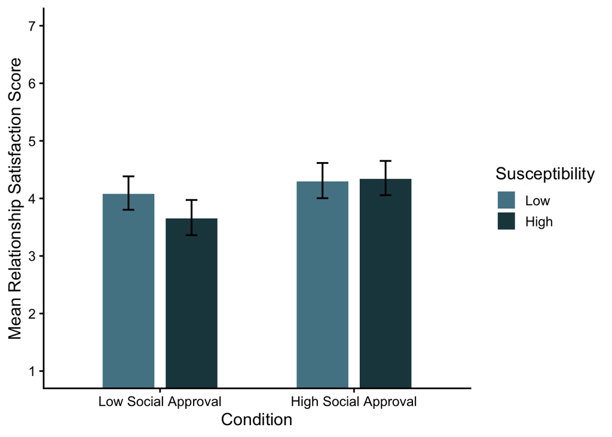

```r
p_ras_bar <- ggplot(
  as.data.frame(emmeans(a1_ras, ~ condition * suscep_msplit)),
  aes(
    x = condition,
    y = emmean,
    fill = suscep_msplit
  )
) +
  geom_col(
    position = position_dodge(width = 0.65),
    width = 0.55,
    color = "white"
  ) +
  geom_errorbar(
    aes(
      ymin = lower.CL,
      ymax = upper.CL
    ),
    position = position_dodge(width = 0.65),
    width = 0.12,
    linewidth = 0.7
  ) +
  labs(
    x = "Condition",
    y = "Mean Relationship Satisfaction Score",
    fill = "Susceptibility"
  ) +
  scale_fill_manual(
    values = c(
      "Low" = "#538493",  # YOU CAN CHANGE THESE TWO HEX VALUES TO MATCH YOUR POSTER!
      "High" = "#1F454D"
    )
  ) +
  scale_y_continuous(
    breaks = 1:7
  ) +
  coord_cartesian(
    ylim = c(1, 7)
  ) +
  theme_classic(
    base_size = 14
  )

p_ras_bar
```

The bar graph displays the estimated mean relationship satisfaction scores for each combination of social approval condition and susceptibility group, with 95% confidence interval error bars.

### Export Figures

```r
if (!dir.exists("figures")) {
  dir.create("figures")
}

ggsave(
  filename = "figures/commitment_interaction_plot.svg",
  plot = p_commit_bar,
  width = 7,
  height = 5
)

ggsave(
  filename = "figures/satisfaction_interaction_plot.svg",
  plot = p_ras_bar,
  width = 7,
  height = 5
)
```

The figures were exported as SVG files to the figures folder for use in the accompanying poster and manuscript.

## Results Summary

The primary analyses tested whether social approval condition, susceptibility, and their interaction predicted relationship commitment and satisfaction scores. Two 2x2 ANOVAs were run, and in both models, the social approval condition was the only statistically significant predictor.

Participants who were in the high approval condition reported greater feelings of commitment and relationship satisfaction compared to those in the low approval condition. Susceptibility to interpersonal influence was not a statistically significant predictor of relationship commitment or relationship satisfaction. The interaction between social approval condition and susceptibility group was also not statistically significant, which indicates that the effect of social approval on commitment or satisfaction did not vary widely across the different susceptibility levels. The estimated means and interaction plots above provide the full model output and visualize the pattern of results for each outcome.